# Vertiefende statistische Verfahren

4. Übungsblatt SS 2024

Stefan Kolb, Joachim Waltl

# Allgemeine Information

Alle Aufgaben sind mit R zu lössen, wenn nicht explizit anders angegeben. Die Berechnungen sollen nachvollziehbar und dokumentiert sein. Um die vollständige Punktezahl zu erreichen, müssen alle Ergebnisse und Fragen entsprechend interpretiert bzw. beantwortet werden. Code alleine ist nicht ausreichend! Die Abgabe erfolgt über Moodle entsprechend der Abgaberichtlinien als pdf und Rmd File. Bitte inkludieren Sie namentlich alle beteiligten Gruppenmitglieder sowohl im Bericht als auch im Source Code. Die jeweiligen Datensätze die für diese Übung relevant sind finden Sie ebenfalls in Moodle.

# (Aufgabe 1) Datensatz: Reaven and Miller Diabetes Daten

Verwenden Sie den Datensatz `diabetes_RM.csv`. Der Datensatz enthält fünf Messungen, die an 145 nicht adipösen erwachsenen Patienten durchgeführt wurden, die in drei Gruppen eingeteilt wurden.

Die drei primären Variablen sind die Glukoseintoleranz, die Insulinantwort auf orale Glukose und die Insulinresistenz (gemessen durch die Steady-State-Plasmaglukose, die nach chemischer Suppression der endogenen Insulinsekretion bestimmt wird). Zwei zusätzliche Variablen, das relative Gewicht und die Nüchternplasmaglukose, sind ebenfalls enthalten. Zusammengefasst ergeben sich folgende Prädiktorvariablen:

- `rw`: relatives Gewicht, Verhältnis zwischen aktuellem Gewicht und zu erwartendem Gewicht bei der Körpergröße
- `fpg`: Nüchternglukoselevel im Plasma in mg/dl
- `glucose`: Fläche unter Glukose-Antwort (mg/dl*h) nach 3h oralem Glukosetoleranztest (OGTT)
- `insulin`: Fläche unter der Insulin-Antwort (mg/dl*h) nach OGTT
- `sspg`: Steady-State-Plasmaglukose (mg/dl) als Maß für die Insulinresistenz

```r
# Variable Beschreibungen
descriptions <- get_descriptions()
```

Reaven und Miller [[ref]](https://doi.org/10.1007/BF00423145) wendeten in Anlehnung an Friedman und Rubin (1967) eine Clusteranalyse auf die drei primären Variablen an und identifizierten drei Cluster: “normal”, “chemical” und “overt” diabetsiche Probanden. Die Variable `group` enthält die Klassifizierungen der Probanden in diese drei Gruppen.

# 1 Diskriminanzanalyse [5P]

Führen Sie eine Diskriminanzanalyse unter Berücksichtigung folgender Punkte durch:

```r
# Datensatz laden
diabetes <- read.csv("diabetes_RM.csv")

# Übersicht
str(diabetes)
```

```
## 'data.frame':    145 obs. of  6 variables:
##  $ rw     : num  0.81 0.95 0.94 1.04 1 0.76 0.91 1.1 0.99 0.78 ...
##  $ fpg    : int  80 97 105 90 90 86 100 85 97 97 ...
##  $ glucose: int  356 289 319 356 323 381 350 301 379 296 ...
##  $ insulin: int  124 117 143 199 240 157 221 186 142 131 ...
##  $ sspg   : int  55 76 105 108 143 165 119 105 98 94 ...
##  $ group  : chr  "normal" "normal" "normal" "normal" ...
```

```r
head(diabetes)
```

|  | rw | fpg | glucose | insulin | sspg | group |
| --- | --- | --- | --- | --- | --- | --- |
| 1 | 0.81 | 80 | 356 | 124 | 55 | normal |
| 2 | 0.95 | 97 | 289 | 117 | 76 | normal |
| 3 | 0.94 | 105 | 319 | 143 | 105 | normal |
| 4 | 1.04 | 90 | 356 | 199 | 108 | normal |
| 5 | 1.00 | 90 | 323 | 240 | 143 | normal |
| 6 | 0.76 | 86 | 381 | 157 | 165 | normal |

```r
# Outcomevariable als Faktor definieren
diabetes$group <- as.factor(diabetes$group)

# Zusammenfassung
summary(diabetes)
```

```
##        rw              fpg         glucose          insulin
##  Min.   :0.7100   Min.   : 70   Min.   : 269.0   Min.   : 10.0
##  1st Qu.:0.8800   1st Qu.: 90   1st Qu.: 352.0   1st Qu.:118.0
##  Median :0.9800   Median : 97   Median : 413.0   Median :156.0
##  Mean   :0.9773   Mean   :122   Mean   : 543.6   Mean   :186.1
##  3rd Qu.:1.0800   3rd Qu.:112   3rd Qu.: 558.0   3rd Qu.:221.0
##  Max.   :1.2000   Max.   :353   Max.   :1568.0   Max.   :748.0
##       sspg            group
##  Min.   : 29.0   chemical:36
##  1st Qu.:100.0   normal  :76
##  Median :159.0   overt   :33
##  Mean   :184.2
##  3rd Qu.:257.0
##  Max.   :480.0
```

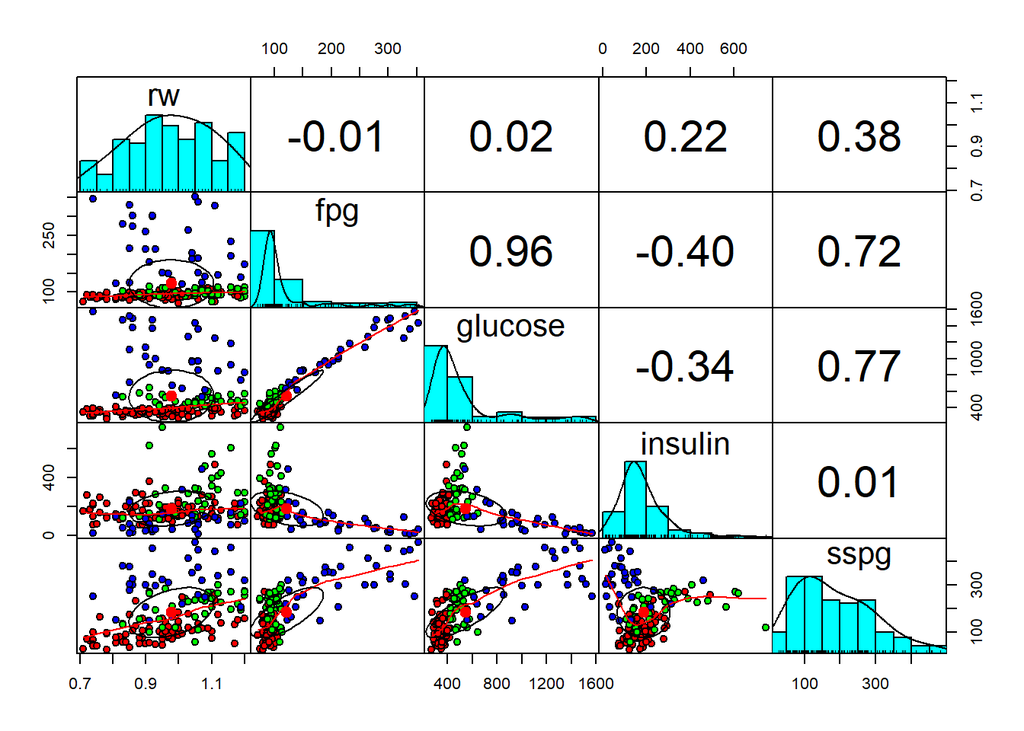

```r
pairs.panels(diabetes[1:5],
             gap = 0,
             bg = c("green","red","blue")[diabetes$group],
             pch = 21)
```

1. Explorative Analyse der Prädiktoren mit Hilfe von Histogrammen. Gibt es Prädiktoren, die bereits eine gute Trennung zwischen den Klassen erlauben?

```r
# Explorative Analyse

# Mittelwerte aller Gruppe für numerische Prädiktoren berechnen

# Tabelle
aggregate(cbind(glucose,insulin,fpg,sspg,rw)~group,diabetes,mean)
```

| group | glucose | insulin | fpg | sspg | rw |
| --- | --- | --- | --- | --- | --- |
| chemical | 493.9444 | 288.0000 | 99.30556 | 208.9722 | 1.0558333 |
| normal | 349.9737 | 172.6447 | 91.18421 | 114.0000 | 0.9372368 |
| overt | 1043.7576 | 106.0000 | 217.66667 | 318.8788 | 0.9839394 |

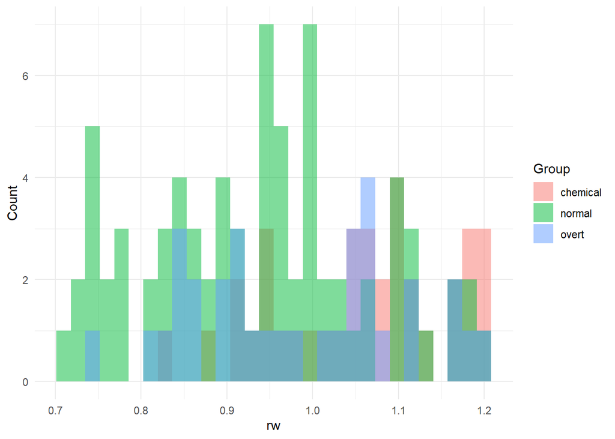

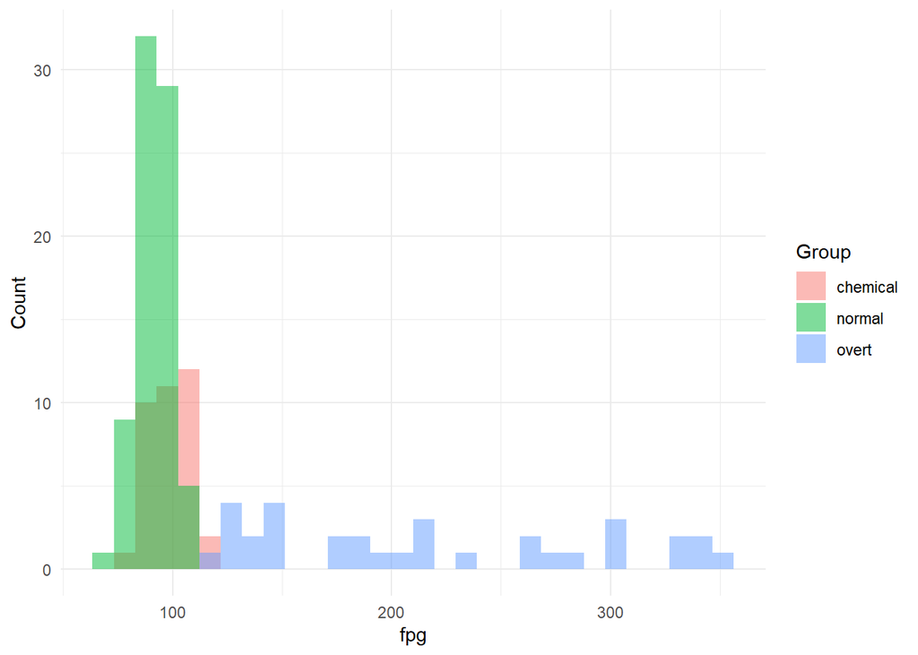

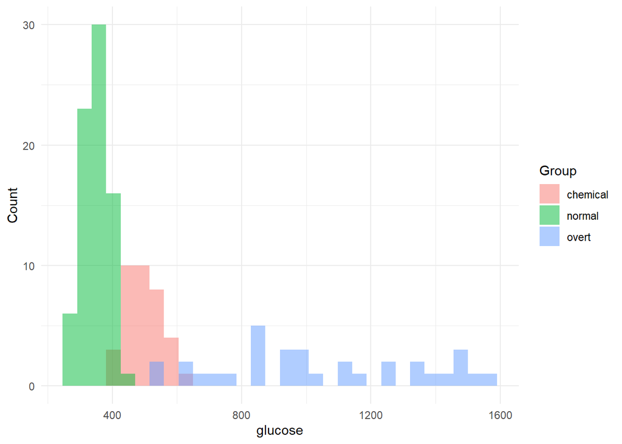

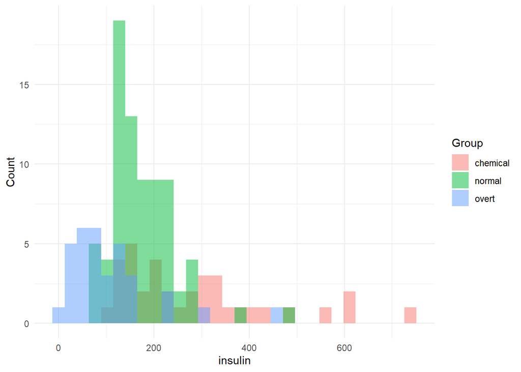

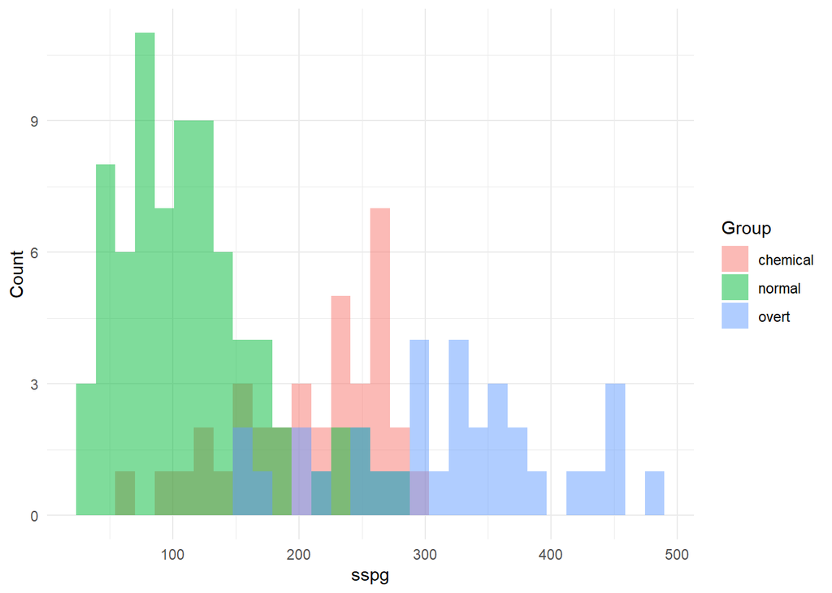

```r
# Histogramme
create_histograms(diabetes)
```

Anhand der Histogramme lässt sich kein Prädiktor identifizieren, der eine gute Trennung zwischen den Klassen erlaubt. Am ehesten ist beim Prädiktor ‘glucose’ eine Abgrenzung der Gruppen erkennbar. Zur explorativen Trennung der Gruppen wird daher der Prädiktor ‘glucose’ mit manuell festgelegten Schwellwerten verwendet.

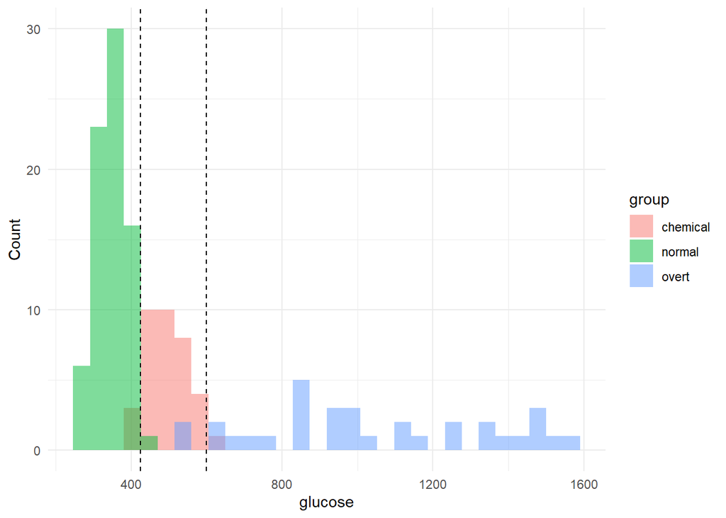

```r
# Explorativer Ansatz zur Trennung der Gruppen
# Grenzen anhand des Prädiktors 'glucose'
grenzen <- c(425,600)

ggplot(diabetes, aes(x = glucose, fill = group)) +
    geom_histogram(position = "identity", alpha = 0.5, bins = 30) +
    labs(x = "glucose", y = "Count", fill = "group") +
    # Grenze einfügen
    geom_vline(xintercept = grenzen, linetype = "dashed", color = "black") +
    theme_minimal()
```

```r
# Klassifizierung der Gruppen anhand der Grenzen
diabetes$group_K1<- ifelse(diabetes$glucose < grenzen[1], "normal",
                             ifelse(diabetes$glucose < grenzen[2], "chemical",
                                    "overt"))

# Genauigkeit der Klassifizierung
mean(diabetes$group_K1 == diabetes$group)
```

```
## [1] 0.9586207
```

Durch die Klassifizierung anhand des Prädiktors ‘glucose’ konnte eine Genauigkeit von knapp 96% erreicht werden. Dies deutet darauf hin, dass der Prädiktor ‘glucose’ tatsächlich bereits eine recht gute Trennung der Gruppen ermöglicht. Im nächsten Schritt wird eine Diskriminanzanalyse (LDA) durchgeführt, um hoffentlich eine noch akuratere Klassifizierung der Gruppen zu erreichen.

2. Überprüfen Sie ob die Vorraussetzungen für eine LDA gegeben sind und führen Sie eine Standardisierung der Daten durch.

```r
# Überprüfen der Voraussetzungen

# Normalverteilung der Prädiktoren (Visuell u. Konservativ)

print("p-Werte des Shapiro-Wilk-Tests: ")
```

```
## [1] "p-Werte des Shapiro-Wilk-Tests: "
```

```
## [1] "p-Wert für rw : 0.00852897444259993"
```

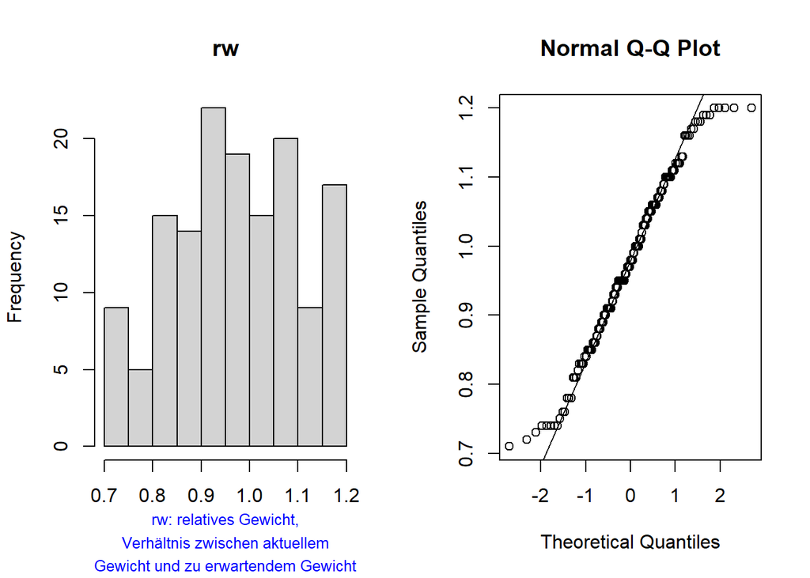

```
## [1] "p-Wert für fpg : 1.2632736568106e-17"
```

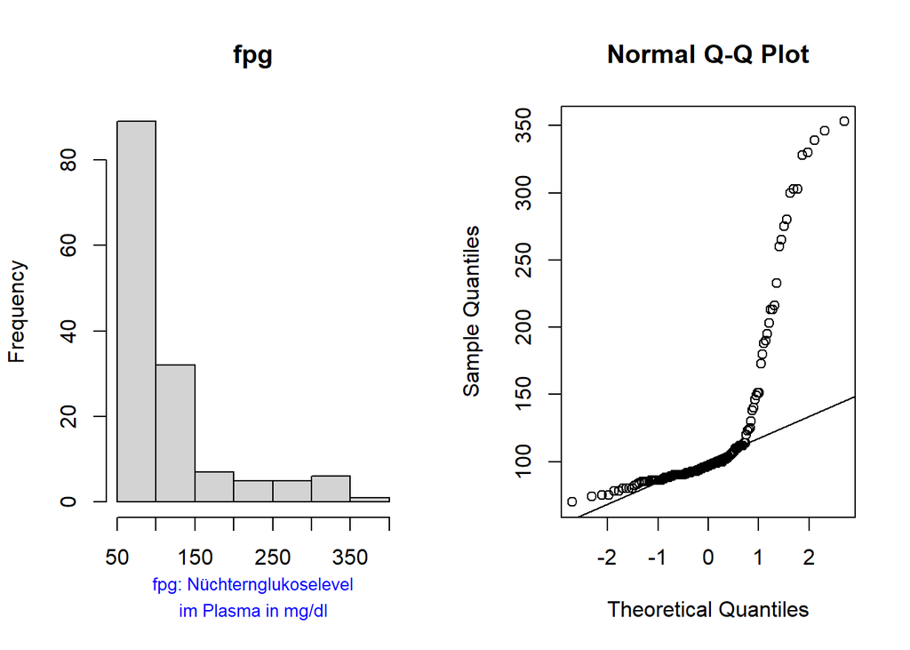

```
## [1] "p-Wert für glucose : 3.15570068501942e-15"
```

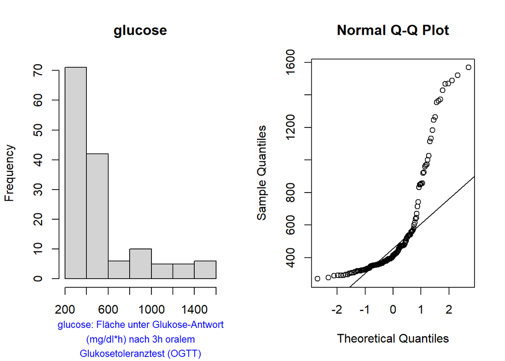

```
## [1] "p-Wert für insulin : 9.70364408387467e-11"
```

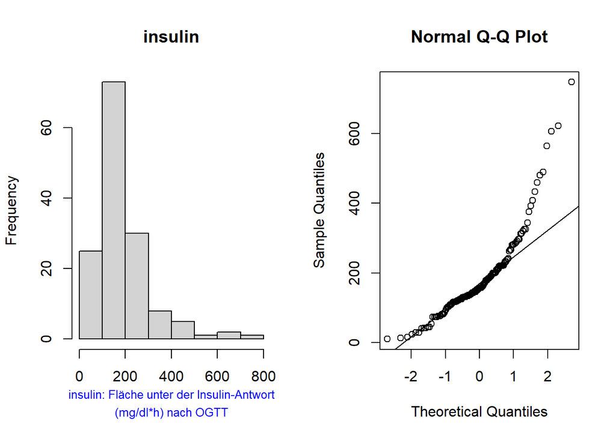

```
## [1] "p-Wert für sspg : 1.24618944438909e-05"
```

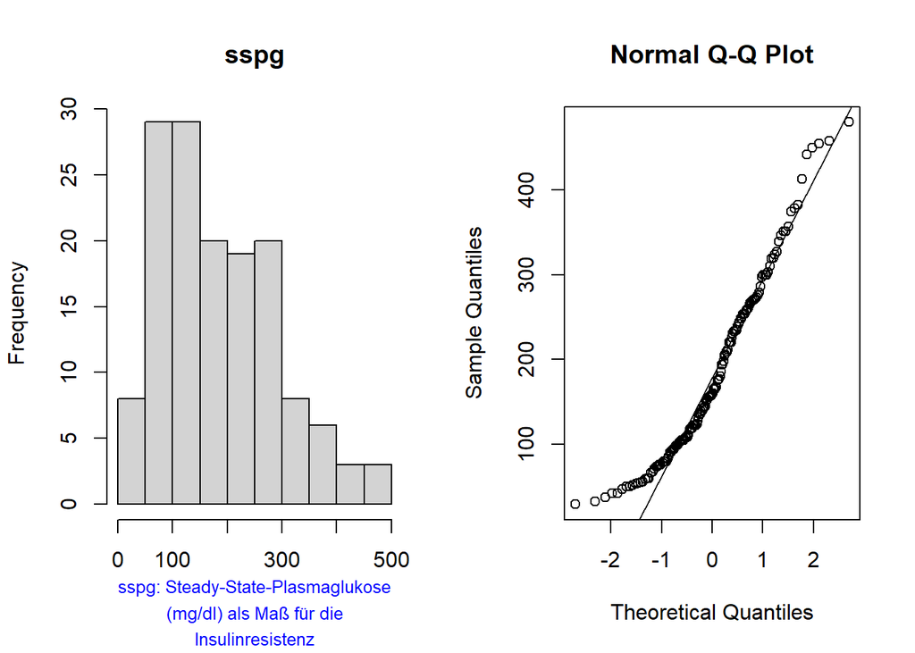

```r
for (i in 1:5) {

  #Shapiro-Wilk-Test
  sw_p <- shapiro.test(diabetes[,i])$p.value
  print(paste("p-Wert für", colnames(diabetes)[i], ":", sw_p))


  par(mfrow = c(1,2))
  # Histogramme
  hist(diabetes[,i], main = colnames(diabetes)[i], xlab = "")
   for (j in 1:length(descriptions[[i]])) {
    mtext(descriptions[[i]][j], side = 1, line = 1 + j, cex = 0.8, col =   "blue")
  }
  # QQ-Plots
  qqnorm(diabetes[,i])
  qqline(diabetes[,i])

}
```

```r
# Überprüfung der Multivariaten Normalverteilung
mvn_test <- MVN::mvn(diabetes[, sapply(diabetes, is.numeric)], mvnTest = "hz")
print(mvn_test)
```

```
## $multivariateNormality
##            Test       HZ p value MVN
## 1 Henze-Zirkler 3.272543       0  NO
##
## $univariateNormality
##               Test  Variable Statistic   p value Normality
## 1 Anderson-Darling    rw        0.6311  0.0982      YES
## 2 Anderson-Darling    fpg      21.8353  <0.001      NO
## 3 Anderson-Darling  glucose    15.4117  <0.001      NO
## 4 Anderson-Darling  insulin     5.4330  <0.001      NO
## 5 Anderson-Darling   sspg       2.2421  <0.001      NO
##
## $Descriptives
##           n        Mean     Std.Dev Median    Min    Max   25th   75th
## rw      145   0.9773103   0.1292352   0.98   0.71    1.2   0.88   1.08
## fpg     145 121.9862069  63.9304077  97.00  70.00  353.0  90.00 112.00
## glucose 145 543.6137931 316.9508634 413.00 269.00 1568.0 352.00 558.00
## insulin 145 186.1172414 120.9351584 156.00  10.00  748.0 118.00 221.00
## sspg    145 184.2068966 106.0298632 159.00  29.00  480.0 100.00 257.00
##               Skew   Kurtosis
## rw      -0.1161301 -0.8665719
## fpg      2.2287483  4.0105224
## glucose  1.7796189  2.1620152
## insulin  1.7960220  4.4484613
## sspg     0.6884820 -0.2335819
```

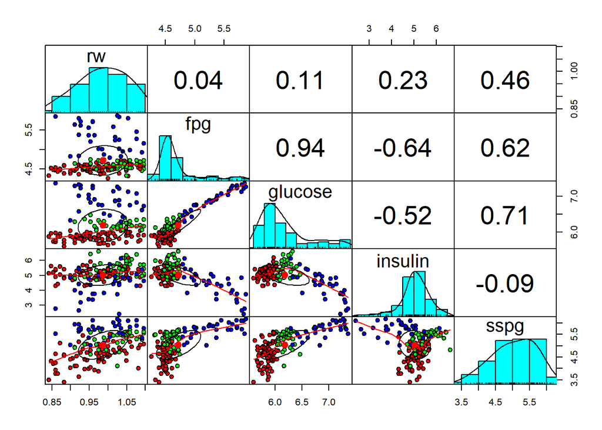

```r
# Transformieren der Daten
diabetes_trans <- diabetes %>%
  mutate(glucose  = log(glucose+1),
         fpg = log(fpg+1),
         sspg  = log(sspg + 1),
         insulin = log(insulin + 1),
         rw = sqrt(rw),
         group = as.factor(group))

# Überprüfung der Transformation
pairs.panels(diabetes_trans[1:5],
             gap = 0,
             bg = c("green","red","blue")[diabetes_trans$group],
             pch = 21)
```

Selbst nach der Transformation der Daten sind die Prädiktoren ‘glucose’, ‘fpg’ und ‘insulin’ noch immer nicht normalverteilt. Die Diskriminanzanalyse wird dennoch durchgeführt, da sie robust gegenüber Verletzungen der Normalverteilung ist.

```r
# Korrelationen
cor_matrix <- cor(diabetes[,1:5])
print(cor_matrix)
```

```
##                   rw          fpg    glucose      insulin        sspg
## rw       1.000000000 -0.008813193  0.0239843  0.222237813 0.384319804
## fpg     -0.008813193  1.000000000  0.9646281 -0.396234858 0.715480192
## glucose  0.023984304  0.964628091  1.0000000 -0.337020435 0.770942459
## insulin  0.222237813 -0.396234858 -0.3370204  1.000000000 0.007914263
## sspg     0.384319804  0.715480192  0.7709425  0.007914263 1.000000000
```

Die Korrelationsmatrix zeigt, dass der Prädiktor ‘glucose’ eine starke positive Korrelation mit den Prädiktoren ‘fpg’(0.96) und ‘sspg’(0.77) aufweist.

```r
# Kovarianzen
cov_matrix <- cov(diabetes[,1:5])
print(cov_matrix)
```

```
##                  rw           fpg       glucose       insulin         sspg
## rw       0.01670174 -7.281513e-02  9.824262e-01      3.473373     5.266255
## fpg     -0.07281513  4.087097e+03  1.954606e+04  -3063.463649  4849.905651
## glucose  0.98242625  1.954606e+04  1.004578e+05 -12918.162739 25908.490182
## insulin  3.47337308 -3.063464e+03 -1.291816e+04  14625.312548   101.482519
## sspg     5.26625479  4.849906e+03  2.590849e+04    101.482519 11242.331897
```

```r
# Überprüfung der Homogenität der Kovarianzen
boxM_test <- boxM(diabetes[, sapply(diabetes, is.numeric)], diabetes$group)
print(boxM_test)
```

```
##
##  Box's M-test for Homogeneity of Covariance Matrices
##
## data:  diabetes[, sapply(diabetes, is.numeric)]
## Chi-Sq (approx.) = 396.8, df = 30, p-value < 2.2e-16
```

Der Box-M-Test zeigt, dass die Kovarianzmatrizen der Gruppen nicht gleich sind. Dies bedeutet, dass die Annahme der Homogenität der Kovarianzmatrizen verletzt ist. Streng genommen sind die Voraussetzungen für eine LDA nicht gegeben. Da die LDA in Klassifizierungsaufgaben jedoch robust gegenüber Verletzungen der Normalverteilung und Homogenität der Kovarianzen ist, wird die LDA dennoch durchgeführt.

Um eine bessere Vergleichbarkeit der Prädiktoren zu gewährleisten, werden die Daten standardisiert.

```r
# Standardisierung der Daten (mittels preProcess-Funktion)
diabetes.prePro <- preProcess(diabetes[, sapply(diabetes, is.numeric)], method = c("center", "scale"))
# Anwenden des Preprocessers
diabetes.pre <- predict(diabetes.prePro, diabetes[, sapply(diabetes, is.numeric)])
# Hinzufügen der Gruppe
diabetes.pre$group <- as.factor(diabetes$group)

# Alternative: Standardisieren in data.frame (mittels Scale-Funktion)(Transformierte Daten)
diabetes_trans.pre1<-data.frame(rw=scale(diabetes_trans$rw),
                         fpg=scale(diabetes_trans$fpg),
                         glucose=scale(diabetes_trans$glucose),
                         insulin=scale(diabetes_trans$insulin),
                         sspg=scale(diabetes_trans$sspg),
                         group=diabetes_trans$group)
```

3. Unterteilen sie die gesamten Daten in Trainings- und Test-Daten und führen Sie in der weiteren Folge eine Klassifizierung mit einer LDA durch. Evaluieren Sie die Perfomance der Klassifizierung und stellen Sie die Ergebnisse graphisch dar (Darstellung der Projektionen, Partition Plot).

```r
# Splitten der Daten in Trainings- und Testdaten (80/20)
set.seed(42) # Für Reproduzierbarkeit

trainIndex <- sample(1:145, 0.8 * 145, replace = FALSE)
trainData <- diabetes.pre[ trainIndex,]
testData  <- diabetes.pre[-trainIndex,]

# Splitten der transformierten Daten
set.seed(42)
trainIndex <- sample(1:145, 0.8 * 145, replace = FALSE)
trainData_t <- diabetes_trans.pre1[ trainIndex,]
testData_t <- diabetes_trans.pre1[-trainIndex,]
```

Nachdem die Daten in Trainings- und Testdaten aufgeteilt wurden, wird die LDA durchgeführt.

```r
# LDA (Daten ohne Transformation)
lda_m1 <- lda(group ~ glucose + fpg + insulin + sspg + rw, data = trainData)
# LDA (Daten mit Transformation)
lda_m2 <- lda(group ~ glucose + fpg + insulin + sspg + rw, data = trainData_t)

    # LDA nur mit Hauptvariablen
    lda_gis <- lda(group ~ glucose + rw + insulin + sspg, data = trainData)
    lda_gis.p <- predict(lda_gis, newdata = trainData)

# Zusammenfassung des Modells
lda_m1
```

```
## Call:
## lda(group ~ glucose + fpg + insulin + sspg + rw, data = trainData)
##
## Prior probabilities of groups:
##  chemical    normal     overt
## 0.2586207 0.5431034 0.1982759
##
## Group means:
##             glucose        fpg    insulin       sspg          rw
## chemical -0.1527486 -0.3392158  1.0392574  0.2605534  0.60888705
## normal   -0.6117151 -0.4916385 -0.1072838 -0.6407351 -0.35379707
## overt     1.5311498  1.4345199 -0.6513359  1.2708648  0.08809756
##
## Coefficients of linear discriminants:
##                 LD1        LD2
## glucose  4.87591983  1.8677167
## fpg     -2.55596630 -1.8956161
## insulin -0.07988361  0.8369985
## sspg     0.25821227 -0.1977281
## rw       0.25603990  0.5437438
##
## Proportion of trace:
##   LD1   LD2
## 0.885 0.115
```

```r
lda_m2
```

```
## Call:
## lda(group ~ glucose + fpg + insulin + sspg + rw, data = trainData_t)
##
## Prior probabilities of groups:
##  chemical    normal     overt
## 0.2586207 0.5431034 0.1982759
##
## Group means:
##              glucose        fpg     insulin       sspg          rw
## chemical  0.04809973 -0.2918910  0.85407495  0.4198356  0.60784793
## normal   -0.71483447 -0.5589182  0.08244404 -0.6318908 -0.35259786
## overt     1.58306779  1.5494931 -0.85249480  1.0816803  0.09572234
##
## Coefficients of linear discriminants:
##                 LD1         LD2
## glucose  3.48047922  1.93046492
## fpg     -0.59143119 -1.95343959
## insulin  0.08203518  0.76539026
## sspg     0.05858524 -0.09275069
## rw       0.17809750  0.43479094
##
## Proportion of trace:
##    LD1    LD2
## 0.9027 0.0973
```

```r
lda_gis
```

```
## Call:
## lda(group ~ glucose + rw + insulin + sspg, data = trainData)
##
## Prior probabilities of groups:
##  chemical    normal     overt
## 0.2586207 0.5431034 0.1982759
##
## Group means:
##             glucose          rw    insulin       sspg
## chemical -0.1527486  0.60888705  1.0392574  0.2605534
## normal   -0.6117151 -0.35379707 -0.1072838 -0.6407351
## overt     1.5311498  0.08809756 -0.6513359  1.2708648
##
## Coefficients of linear discriminants:
##                 LD1        LD2
## glucose -2.18679912 -0.2761453
## rw      -0.17988298 -0.6064187
## insulin  0.03757696 -1.0111732
## sspg    -0.28425918  0.1540434
##
## Proportion of trace:
##    LD1    LD2
## 0.8783 0.1217
```

```r
# Klasse der Trainingsdaten vorhersagen
lda_m1.p <- predict(lda_m1, newdata = trainData)
lda_gis.p <- predict(lda_gis, newdata = trainData)
lda_m2.p <- predict(lda_m2, newdata = trainData_t)

head(lda_m1.p$posterior)
```

```
##         chemical       normal        overt
## 49  1.913845e-03 9.980862e-01 5.072943e-11
## 65  9.850652e-01 1.425041e-02 6.844357e-04
## 74  2.722844e-02 9.727715e-01 1.214273e-08
## 122 4.933605e-04 1.436295e-07 9.995065e-01
## 145 3.367075e-11 2.716493e-15 1.000000e+00
## 128 2.003124e-03 9.987091e-08 9.979968e-01
```

```r
head(lda_m1.p$class)
```

```
## [1] normal   chemical normal   overt    overt    overt
## Levels: chemical normal overt
```

```r
# Genauigkeit des Modells überprüfen
print(paste("Model 1 (alle Parameter):",mean(lda_m1.p$class == trainData_t$group)))
```

```
## [1] "Model 1 (alle Parameter): 0.905172413793103"
```

```r
print(paste("Model 2 (trans. Parameter):",mean(lda_m2.p$class == trainData_t$group)))
```

```
## [1] "Model 2 (trans. Parameter): 0.931034482758621"
```

```r
print(paste("Model 3 (nur Hauptparameter):",mean(lda_gis.p$class == trainData_t$group)))
```

```
## [1] "Model 3 (nur Hauptparameter): 0.844827586206897"
```

Da durch das Modell mit den transformierten Daten eine höhere Genauigkeit erreicht werden konnte, wird neben dem Model 1 auch dieses Modell für die weitere Analyse und Klassifikation der Testdaten verwendet.

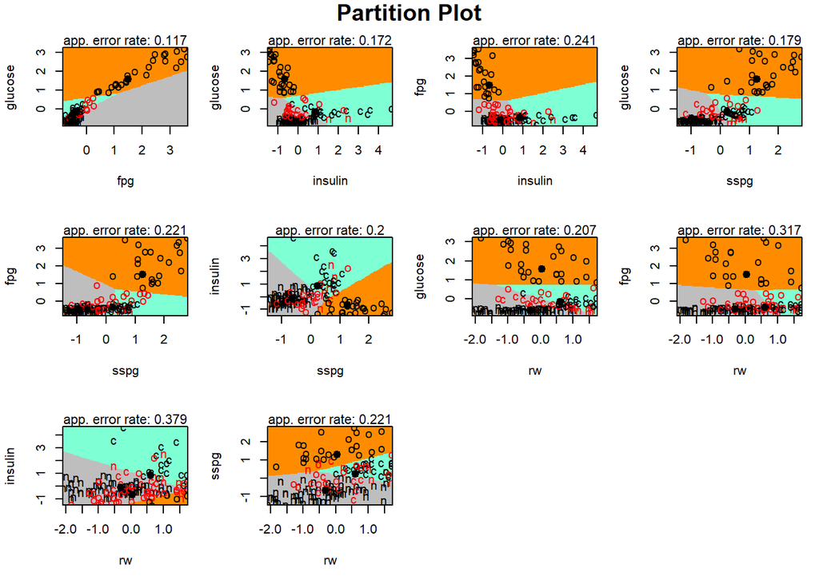

```r
#lda Trennung darstellen
# Partition Plot
partimat(group ~ glucose + fpg + insulin + sspg + rw,
         data = diabetes.pre, method = "lda",
         image.colors = c("aquamarine", "gray", "darkorange"))
```

```r
# Projektionen
head(lda_m1.p$x) #LD1 und LD2
```

```
##           LD1         LD2
## 49  -2.384426 -0.41510594
## 65   1.022330  1.11994323
## 74  -1.479451 -0.06415764
## 122  4.007336 -0.35796333
## 145  6.784049 -2.98729450
## 128  4.098586  0.47514019
```

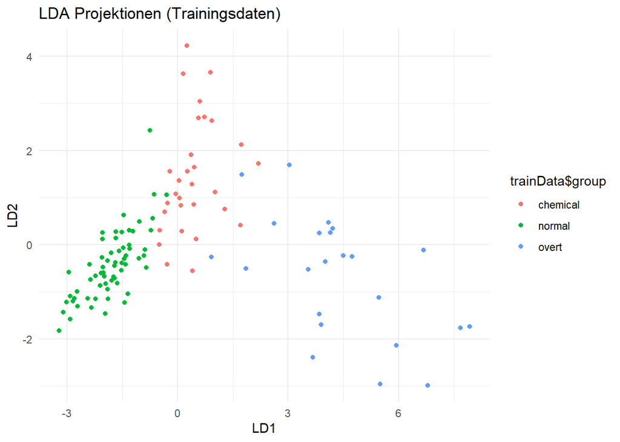

```r
# lda_m1.p$x als data.frame
lda_m1.p$x <- as.data.frame(lda_m1.p$x)

#projektionen graphisch darstellen
ggplot(lda_m1.p$x, aes(x = LD1, y = LD2, color = trainData$group)) +
  geom_point() +
  ggtitle("LDA Projektionen (Trainingsdaten)") +
  xlab("LD1") +
  ylab("LD2") +
  theme_minimal()
```

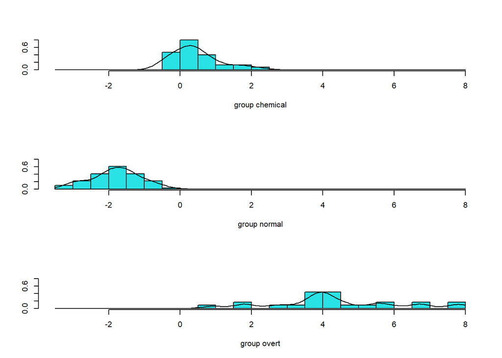

```r
# Histogramme der Projektionen
ldahist(lda_m1.p$x[,1], g = trainData$group,type = "both")
```

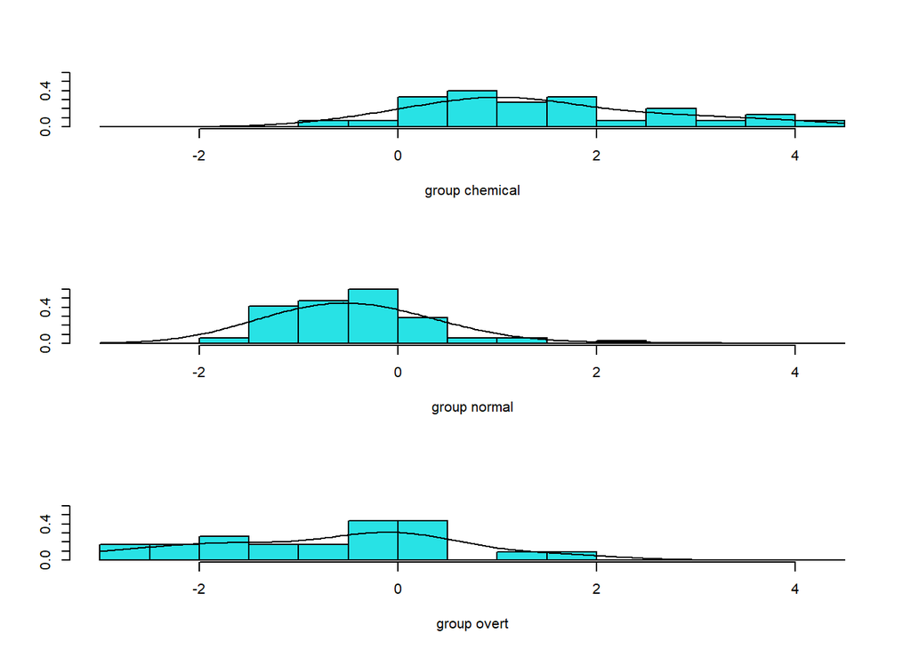

```r
ldahist(lda_m1.p$x[,2], g = trainData$group, type = "both")
```

```r
# Vorhersage auf Testdaten
lda_pred <- predict(lda_m1, newdata = testData)
lda_pred2 <- predict(lda_m2, newdata = testData_t)

head(lda_pred$posterior)
```

```
##        chemical    normal        overt
## 7  0.0023214274 0.9976786 1.226958e-10
## 11 0.0075812773 0.9924187 4.494838e-10
## 12 0.0001244314 0.9998756 3.381976e-12
## 23 0.0042265730 0.9957734 3.851015e-10
## 28 0.0221860832 0.9778139 3.138812e-09
## 37 0.0650780301 0.9349220 4.766249e-09
```

```r
head(lda_pred$class)
```

```
## [1] normal normal normal normal normal normal
## Levels: chemical normal overt
```

```r
# Genauigkeit des Modells überprüfen
ac_lda <-mean(lda_pred$class == testData$group) # 93%
ac_lda_t <-mean(lda_pred2$class == testData_t$group) # 90%

# Projektionen der Testdaten
lda_pred$x #LD1 und LD2
```

```
##             LD1         LD2
## 7   -2.24386940 -0.47959353
## 11  -2.01843419 -0.11404898
## 12  -2.85829320 -1.30950936
## 23  -2.05461844 -0.38458332
## 28  -1.69373155  0.07952616
## 37  -1.59976577  0.56579969
## 39  -1.69076890 -0.70491935
## 45  -2.88284697 -2.05658411
## 51  -2.36094302 -1.04594732
## 52  -2.09346570  0.53144272
## 56  -1.91578422 -0.19597619
## 59   0.01726209  0.18050636
## 62   0.13598549  0.54041313
## 66  -0.11855509  0.28833208
## 67  -0.36001531  0.48249638
## 70  -0.83240309 -0.48334119
## 83   0.32288046  0.88685053
## 91   1.57965994  1.45271176
## 107  1.70127938  0.30362268
## 116  8.38184003 -1.19978015
## 121  3.39277350  0.21975105
## 126  6.95519813 -1.40627326
## 130  4.59255271  0.74175877
## 131  0.33737152  1.86909949
## 133  7.02632877 -2.43999746
## 134 -0.03661093 -1.05386480
## 139  4.88880623 -3.09639799
## 140  6.24966915 -0.99043375
## 143  3.94861736 -1.39131919
```